# 01-Pointing_gestures_and_common_ground_duration

Olena Tykhostup

2022-01-29

This is the code used for data analysis reported in Chapter 6 of the dissertation titled ‘Multimodal Annotation and Analysis of a Narrative Problem-Solving Task in English, Idi, and Russian’. This script conducts a statistical analysis on the dataset that includes the durations of pointing gestures in the three languages and the annotations of information status of co-produced spoken expressions. Initially, the data is formatted and explored by plotting distributions. This is followed by fitting regression models to understand the effects of different variables on the duration of pointing gestures in three languages. ## Load the packages

```r
library(here)
library(lubridate)
library(ggplot2)
library(tidyverse)
library(sjPlot) # for tab_model and plot_model functions
library(lme4)
library(car)
library(ggbeeswarm)
library(ggpubr)
```

## Define the color palette

```r
customColors <- c("#183A5A", "#EFB758", "#C34129", "#E2DBC9")
```

## Load the data

English, Idi, Russian data samples, both experiment phases.

```r
pointCommonGroundData <- read.csv(here("data", "FPPT-EIR-Full-Annotations.csv"))
```

## Prepare the data for analysis

```r
cleanDataForAnalysis <- pointCommonGroundData %>%
  mutate_at(vars(begin, end), ~ as.POSIXct(., format = "%Y-%m-%dT%H:%M:%SZ")) %>% # transform time columns to POSIXct
  mutate_at(vars(speaker, trial, affil, infstat, shape, effort, traj, orient, target, cards, lang, phase),funs(factor(.))) %>% # transform all columns into factors (card stays character)
  mutate(affwords = str_count(coart, fixed(".")),
         affwords = as.integer(affwords + 1))  # a column that contains number of words in affiliate
```

## Inspect the df

```r
str(cleanDataForAnalysis)
```

```
## 'data.frame':    1449 obs. of  17 variables:
##  $ speaker : Factor w/ 16 levels "FPPTER106","FPPTER107",..: 1 1 1 1 1 1 1 1 1 1 ...
##  $ begin   : POSIXct, format: "2024-01-09 23:15:04" "2024-01-09 23:17:30" ...
##  $ end     : POSIXct, format: "2024-01-09 23:15:05" "2024-01-09 23:17:32" ...
##  $ dur     : int  555 1712 1068 3885 1295 595 455 555 3160 1030 ...
##  $ trial   : Factor w/ 14 levels "FPPT-ENG-Phase1-20181219-v7-ALS-v1.eaf",..: 1 1 1 1 1 1 1 1 1 1 ...
##  $ coart   : chr  "he.s.got.a.drink.in.his.hand" "he.goes.to.jail" "that.s.him" "walking.back" ...
##  $ affil   : Factor w/ 4 levels "ambiguous","noun",..: 1 1 4 3 4 3 3 3 3 3 ...
##  $ infstat : Factor w/ 3 levels "new","old","other": 2 2 2 2 3 1 3 3 3 3 ...
##  $ shape   : Factor w/ 3 levels "index","other",..: 1 1 1 1 3 3 1 1 1 1 ...
##  $ effort  : Factor w/ 2 levels "contact","nocontact": 2 2 2 1 1 1 1 1 1 1 ...
##  $ traj    : Factor w/ 2 levels "complex","simple": 2 2 2 2 2 2 2 2 2 2 ...
##  $ orient  : Factor w/ 3 levels "down","up","vertical": 1 3 1 1 1 1 1 1 1 1 ...
##  $ target  : Factor w/ 4 levels "card","individ",..: 3 3 3 2 1 1 1 1 1 1 ...
##  $ cards   : Factor w/ 2 levels "multiple","single": 2 1 1 1 1 1 1 1 1 1 ...
##  $ lang    : Factor w/ 3 levels "eng","idi","rus": 1 1 1 1 1 1 1 1 1 1 ...
##  $ phase   : Factor w/ 2 levels "H","S": 2 2 2 1 1 2 2 2 1 2 ...
##  $ affwords: int  8 4 3 2 1 1 1 1 1 1 ...
```

```r
head(cleanDataForAnalysis)
```

```
##     speaker               begin                 end  dur
## 1 FPPTER106 2024-01-09 23:15:04 2024-01-09 23:15:05  555
## 2 FPPTER106 2024-01-09 23:17:30 2024-01-09 23:17:32 1712
## 3 FPPTER106 2024-01-09 23:17:39 2024-01-09 23:17:40 1068
## 4 FPPTER106 2024-01-09 23:18:04 2024-01-09 23:18:08 3885
## 5 FPPTER106 2024-01-09 23:18:08 2024-01-09 23:18:09 1295
## 6 FPPTER106 2024-01-09 23:18:09 2024-01-09 23:18:10  595
##                                    trial                        coart     affil
## 1 FPPT-ENG-Phase1-20181219-v7-ALS-v1.eaf he.s.got.a.drink.in.his.hand ambiguous
## 2 FPPT-ENG-Phase1-20181219-v7-ALS-v1.eaf              he.goes.to.jail ambiguous
## 3 FPPT-ENG-Phase1-20181219-v7-ALS-v1.eaf                   that.s.him       pro
## 4 FPPT-ENG-Phase1-20181219-v7-ALS-v1.eaf                 walking.back     other
## 5 FPPT-ENG-Phase1-20181219-v7-ALS-v1.eaf                        there       pro
## 6 FPPT-ENG-Phase1-20181219-v7-ALS-v1.eaf                           --     other
##   infstat shape    effort   traj   orient   target    cards lang phase affwords
## 1     old index nocontact simple     down interior   single  eng     S        8
## 2     old index nocontact simple vertical interior multiple  eng     S        4
## 3     old index nocontact simple     down interior multiple  eng     S        3
## 4     old index   contact simple     down  individ multiple  eng     H        2
## 5   other  palm   contact simple     down     card multiple  eng     H        1
## 6     new  palm   contact simple     down     card multiple  eng     S        1
```

```r
summary(cleanDataForAnalysis)
```

```
##       speaker        begin
##  FPPTRR202:207   Min.   :2024-01-09 23:00:09.00
##  FPPTRR303:205   1st Qu.:2024-01-09 23:04:14.00
##  FPPTER201:168   Median :2024-01-09 23:08:02.00
##  FPPTIR101:167   Mean   :2024-01-09 23:09:34.64
##  FPPTRR105:130   3rd Qu.:2024-01-09 23:13:42.00
##  FPPTRR307:117   Max.   :2024-01-09 23:33:31.00
##  (Other)  :455
##       end                             dur
##  Min.   :2024-01-09 23:00:11.0   Min.   :  150
##  1st Qu.:2024-01-09 23:04:15.0   1st Qu.:  803
##  Median :2024-01-09 23:08:03.0   Median : 1220
##  Mean   :2024-01-09 23:09:36.2   Mean   : 1542
##  3rd Qu.:2024-01-09 23:13:44.0   3rd Qu.: 1884
##  Max.   :2024-01-09 23:33:32.0   Max.   :16982
##
##                                     trial        coart
##  FPPT-RUS-Phase1-20181213-v7.eaf       :247   Length:1449
##  FPPT-ENG-Phase1-20190213-v6-ALS-v1.eaf:234   Class :character
##  FPPT-RUS-Phase1-20181211-v5.eaf       :171   Mode  :character
##  FPPT-IDI-Phase1-20200626-v2.eaf       :167
##  FPPT-RUS-Phase1-20181206-v5.eaf       :140
##  FPPT-ENG-Phase1-20191112-v8-ALS-v1.eaf:119
##  (Other)                               :371
##        affil      infstat      shape            effort         traj
##  ambiguous:410   new  :722   index:1054   contact  :740   complex:490
##  noun     :484   old  :617   other: 129   nocontact:709   simple :959
##  other    :222   other:110   palm : 266
##  pro      :333
##
##
##
##       orient          target         cards      lang     phase
##  down    :1075   card    :355   multiple:712   eng:500   H: 413
##  up      : 138   individ :569   single  :737   idi:167   S:1036
##  vertical: 236   interior:470                  rus:782
##                  other   : 55
##
##
##
##     affwords
##  Min.   : 1.00
##  1st Qu.: 1.00
##  Median : 3.00
##  Mean   : 3.05
##  3rd Qu.: 4.00
##  Max.   :21.00
##
```

```r
sum(is.na(cleanDataForAnalysis))
```

```
## [1] 0
```

## Common ground and pointing gesture duration

## Explore the data

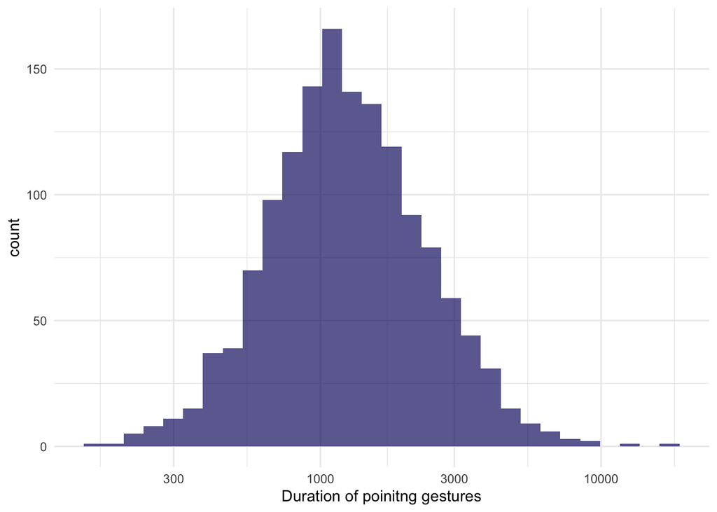

```r
# Plot a histogram of log-transformed durations of pointing gestures
cleanDataForAnalysis %>%
  ggplot(aes(dur + 1)) +
  geom_histogram(fill="midnightblue", alpha=0.7)+
  scale_x_log10() +
  labs(x = "Duration of poinitng gestures") +
  theme_minimal()
```

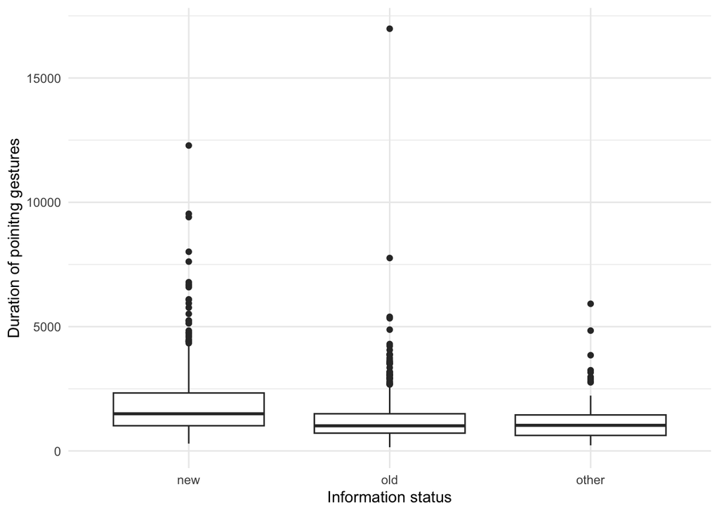

```r
# Plot a boxplot of pointing gesture durations by information status, overlay a linear model
cleanDataForAnalysis %>%
  ggplot(aes(infstat, dur)) +
  geom_boxplot() +
  labs(x = "Information status", y = "Duration of poinitng gestures") +
  geom_smooth(method = "lm")  +
  theme_minimal()
```

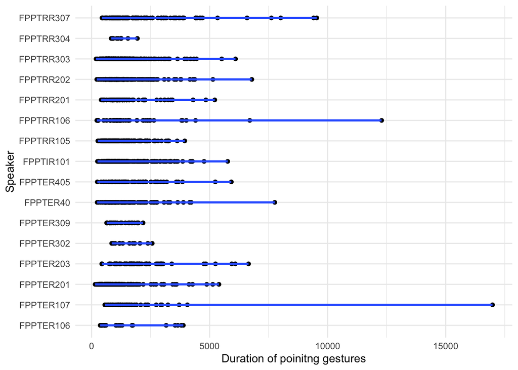

```r
# Plot a scatter plot of pointing gesture durations by speaker, overlay a linear model
cleanDataForAnalysis %>%
  ggplot(aes(dur, speaker)) +
  geom_point() +
  geom_smooth(method = "lm") +
  theme_minimal() +
  labs(x = "Duration of poinitng gestures", y = "Speaker")
```

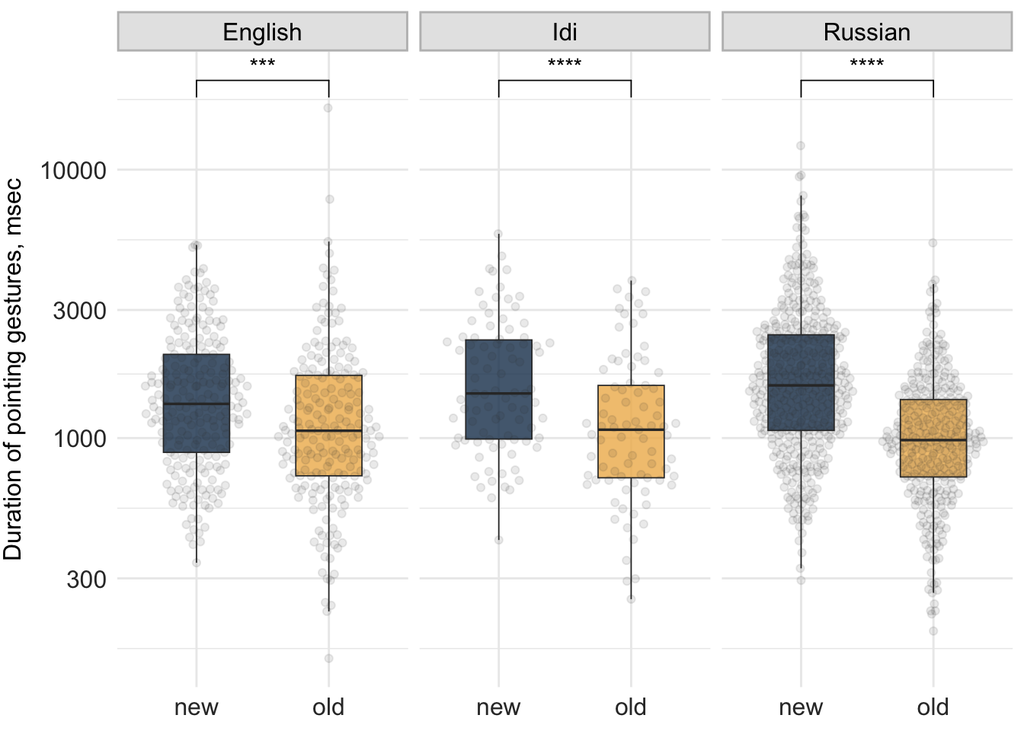

```r
# New facet label names for languange
lang.labs <- c("English", "Idi", "Russian")
names(lang.labs) <- c("eng", "idi", "rus")

my_comparisons = list( c("old", "new"))

plot.dur <- cleanDataForAnalysis %>%
  filter(infstat!= "other") %>%
  ggplot(aes(infstat, dur + 1, color=infstat, fill=infstat)) +
  geom_boxplot(alpha = 0.8, outlier.color = NA, width=0.5, colour="grey20", size=0.3) +
  geom_quasirandom(alpha = 0.1, color = "grey20") +
  scale_fill_manual(values=customColors) +
  facet_grid(~lang, space = "free", scales="free", labeller = labeller(lang=lang.labs)) +
  scale_y_log10() +
  labs(x = NULL, y = "Duration of pointing gestures, msec") +
  theme_minimal() +
  theme(
        legend.position = "none",
        plot.title=element_text(size=12, vjust=2),
        axis.title.x=element_text(vjust=-1, size=12),
        axis.title.y=element_text(vjust=2.5, size=12)) +
  theme(strip.text = element_text(size=12, colour = "black"),
        strip.background = element_rect(fill="grey90", size=1, color = "grey")) +
  theme(axis.text.x = element_text(size=12, color="grey20"),
          axis.text.y = element_text(size=12, color="grey20")) +
  stat_compare_means(comparisons = my_comparisons, method = "t.test",
    label = "p.signif")

# Print plot
plot.dur
```

## Save plot

```r
png(here("figures", "FPPT-Point-dur-by-Lang-boxplot.png"), width = 26, height = 11, units = "cm", res = 500)
plot.dur
dev.off()
```

```r
pdf(here("figures", "FPPT-Point-dur-by-Lang-boxplot.pdf"), width = 6, height = 4)
plot.dur
dev.off()
```

## Prepare the df with English durations

```r
durationDataEng <- cleanDataForAnalysis %>%
  filter(dur <= 7000) %>% # remove 3 outlier values that are longer than 7000 msec
  filter(infstat!= "other") %>%
  filter(lang=="eng") %>%
  select(speaker, dur, infstat, cards)
```

## Simple model with and without random effects

The inclusion of a random effect structure is justified as the AIC of the model with speakers random intercepts is lower than the AIC of the model without random intercepts.

```r
baseModelDurationEng <- glm(dur ~ infstat, family = gaussian, data = durationDataEng)
randomInterceptModelDurationEng <- lme4::lmer(dur ~ infstat + (1|speaker), data = durationDataEng)

AIC(baseModelDurationEng, randomInterceptModelDurationEng)
```

```
##                                 df     AIC
## baseModelDurationEng             3 6945.54
## randomInterceptModelDurationEng  4 6911.91
```

## Model with number of cards on the table as another fixed effect

Adding the number of cards as a fixed effect does not significantly improve the model fit compared to the simpler model that only includes infstat and random intercepts for speaker.

```r
cardsEffectModelDurationEng <- lmer(dur ~ infstat + cards + (1|speaker), data = durationDataEng)
anova(randomInterceptModelDurationEng, cardsEffectModelDurationEng, test = "Chi")
```

```
## Data: durationDataEng
## Models:
## randomInterceptModelDurationEng: dur ~ infstat + (1 | speaker)
## cardsEffectModelDurationEng: dur ~ infstat + cards + (1 | speaker)
##                                 npar    AIC    BIC  logLik deviance  Chisq Df
## randomInterceptModelDurationEng    4 6933.7 6949.9 -3462.9   6925.7
## cardsEffectModelDurationEng        5 6934.9 6955.1 -3462.5   6924.9 0.7746  1
##                                 Pr(>Chisq)
## randomInterceptModelDurationEng
## cardsEffectModelDurationEng         0.3788
```

## Inspect model

```r
summary(randomInterceptModelDurationEng)
```

```
## Linear mixed model fit by REML ['lmerMod']
## Formula: dur ~ infstat + (1 | speaker)
##    Data: durationDataEng
##
## REML criterion at convergence: 6903.9
##
## Scaled residuals:
##     Min      1Q  Median      3Q     Max
## -1.5568 -0.6636 -0.2805  0.4193  4.8037
##
## Random effects:
##  Groups   Name        Variance Std.Dev.
##  speaker  (Intercept)  53252   230.8
##  Residual             832394   912.4
## Number of obs: 420, groups:  speaker, 8
##
## Fixed effects:
##             Estimate Std. Error t value
## (Intercept)  1721.82     108.55  15.861
## infstatold   -362.45      90.34  -4.012
##
## Correlation of Fixed Effects:
##            (Intr)
## infstatold -0.409
```

## Run diagnostics

There is variation in the model’s prediction errors across different speakers, suggesting that speaker-related factors may be influencing the duration predictions. Some speakers consistently exhibit residuals clustered above or below the zero line, indicating a potential systematic bias in the model for those individuals. Levene’s Test suggests that the differences in variances across groups are not statistically significant at the 0.05 level.

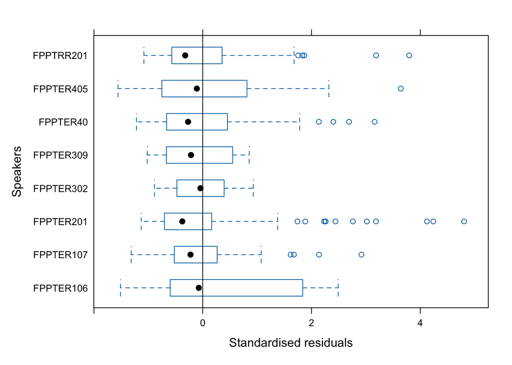

```r
# residuals per speaker
plot(randomInterceptModelDurationEng,
     as.factor(speaker) ~ resid(., scaled=TRUE),
     abline=0,
     pch=16,
     xlab="Standardised residuals",
     ylab="Speakers")
```

```r
# check homogeneity
car::leveneTest(durationDataEng$dur,
                durationDataEng$speaker,
                center = mean)
```

```
## Levene's Test for Homogeneity of Variance (center = mean)
##        Df F value Pr(>F)
## group   7   1.953 0.0602 .
##       412
## ---
## Signif. codes:  0 '***' 0.001 '**' 0.01 '*' 0.05 '.' 0.1 ' ' 1
```

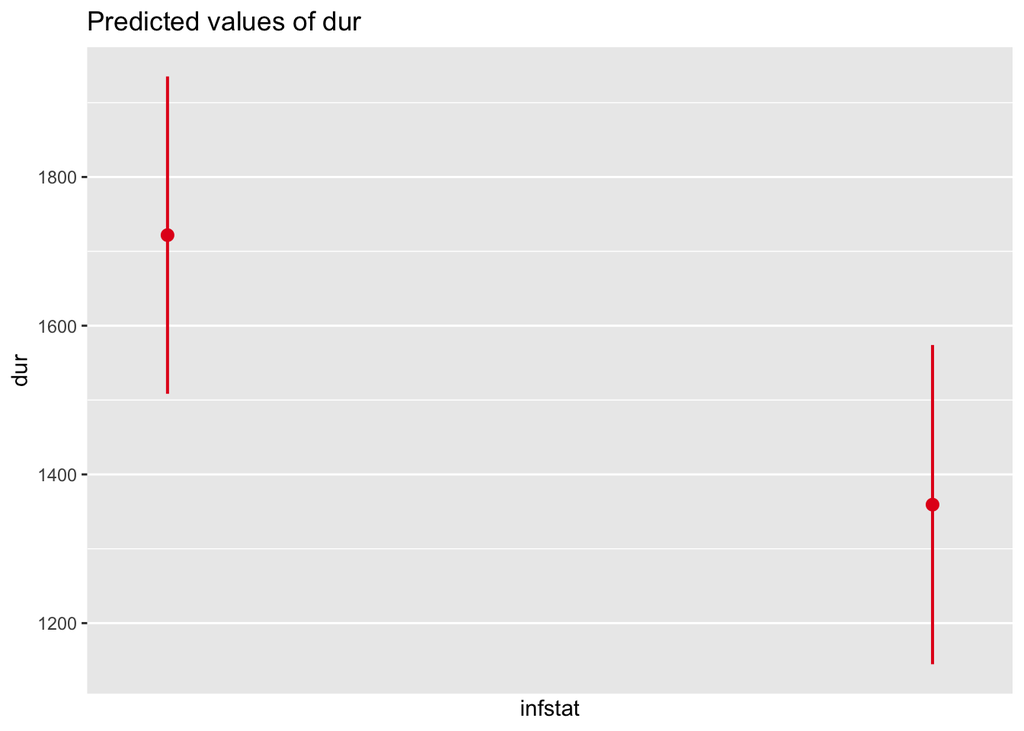

```r
# plot predicted values
sjPlot::plot_model(randomInterceptModelDurationEng,
                   type = "pred",
                   terms = c("infstat")) +
  scale_x_continuous(name = "infstat",
                     breaks = seq(-500, 300, 100),
                     labels = seq(1150, 1950, 100))
```

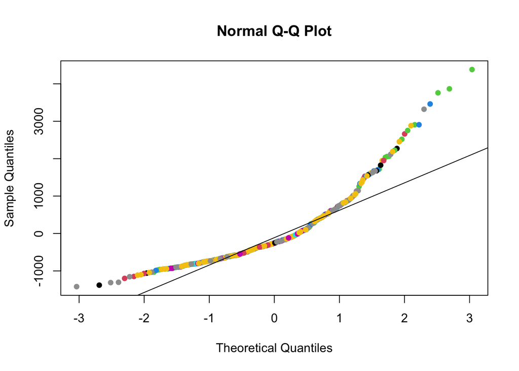

```r
# residuals of fitted values against observed
qqnorm(resid(randomInterceptModelDurationEng),
       pch=16,
       col=durationDataEng$speaker)
qqline(resid(randomInterceptModelDurationEng))
```

## Df with Russian durations

```r
durationDataRus <- cleanDataForAnalysis %>%
  filter(dur <= 7000) %>% # remove 3 outlier values that are longer than 7000 msec
  filter(infstat!= "other") %>%
  filter(lang=="rus") %>%
  select(speaker, dur, cards, infstat, phase)
```

## Simple model with and without random effects

The inclusion of a random effect structure is justified as the AIC of the model with speakers random intercepts is lower than the AIC of the model without random intercepts.

```r
baseModelDurationRus  <- glm(dur ~ infstat, family = gaussian, data = durationDataRus)
randIntModelDurationRus <- lmer(dur ~ infstat + (1|speaker), data = durationDataRus)

AIC(baseModelDurationRus , randIntModelDurationRus)
```

```
##                         df      AIC
## baseModelDurationRus     3 12384.17
## randIntModelDurationRus  4 12320.35
```

## Model with number of cards on the table as another fixed effect

Adding the number of cards as a fixed effect does not significantly improve the model fit compared to the simpler model that only includes infstat and random intercepts for speaker.

```r
cardsEffectModelDurationRus <- lmer(dur ~ infstat + cards + (1|speaker),
                                    data = durationDataRus)

anova(randIntModelDurationRus, cardsEffectModelDurationRus, test = "Chi")
```

```
## refitting model(s) with ML (instead of REML)
```

```
## Data: durationDataRus
## Models:
## randIntModelDurationRus: dur ~ infstat + (1 | speaker)
## cardsEffectModelDurationRus: dur ~ infstat + cards + (1 | speaker)
##                             npar   AIC   BIC  logLik deviance  Chisq Df
## randIntModelDurationRus        4 12342 12361 -6167.1    12334
## cardsEffectModelDurationRus    5 12344 12367 -6166.9    12334 0.5318  1
##                             Pr(>Chisq)
## randIntModelDurationRus
## cardsEffectModelDurationRus     0.4658
```

## Run diagnostics

The diagnostics plots reveal that there is variation in the model’s prediction errors across different speakers, suggesting that speaker-related factors may be influencing the duration predictions. Some speakers consistently exhibit residuals clustered above or below the zero line, indicating a potential systematic bias in the model for those individuals. Levene’s Test suggests that unlike in the English subset of the data, in Russian, the differences in variances across groups are statistically significant at the 0.05 level.

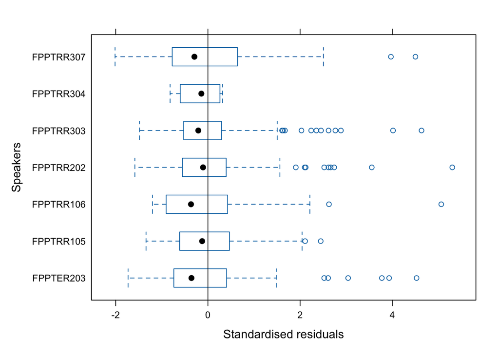

```r
# residuals per speaker
plot(randIntModelDurationRus,
     as.factor(speaker) ~ resid(., scaled=TRUE),
     abline=0,
     pch=16,
     xlab="Standardised residuals",
     ylab="Speakers")
```

```r
# check homogeneity
car::leveneTest(durationDataRus$dur,
                durationDataRus$speaker,
                center = mean)
```

```
## Levene's Test for Homogeneity of Variance (center = mean)
##        Df F value    Pr(>F)
## group   6  5.7475 7.371e-06 ***
##       738
## ---
## Signif. codes:  0 '***' 0.001 '**' 0.01 '*' 0.05 '.' 0.1 ' ' 1
```

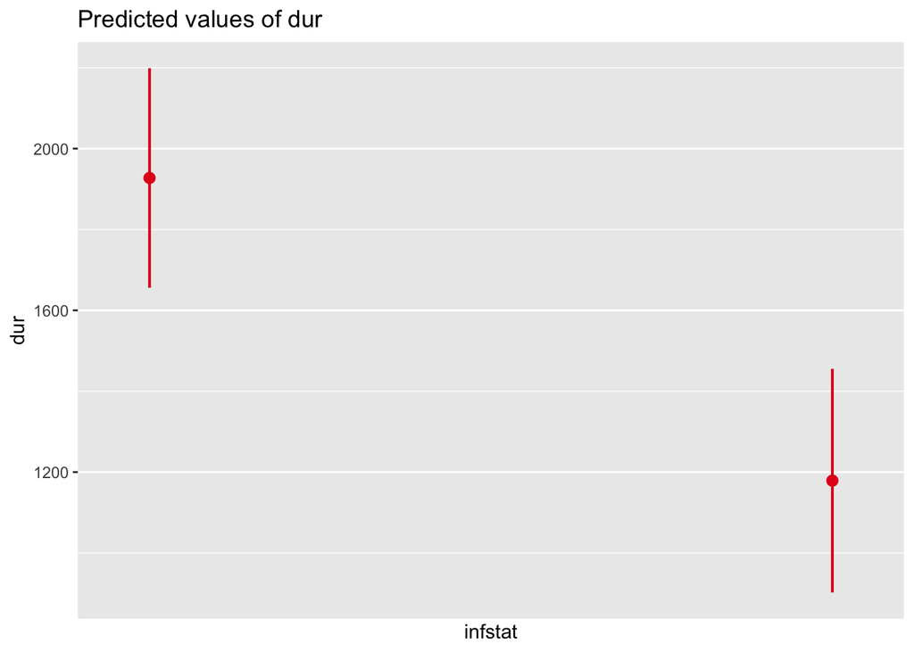

```r
# plot predicted values
sjPlot::plot_model(randIntModelDurationRus,
                   type = "pred",
                   terms = c("infstat")) +
  scale_x_continuous(name = "infstat",
                     breaks = seq(-500, 300, 100),
                     labels = seq(1150, 1950, 100))
```

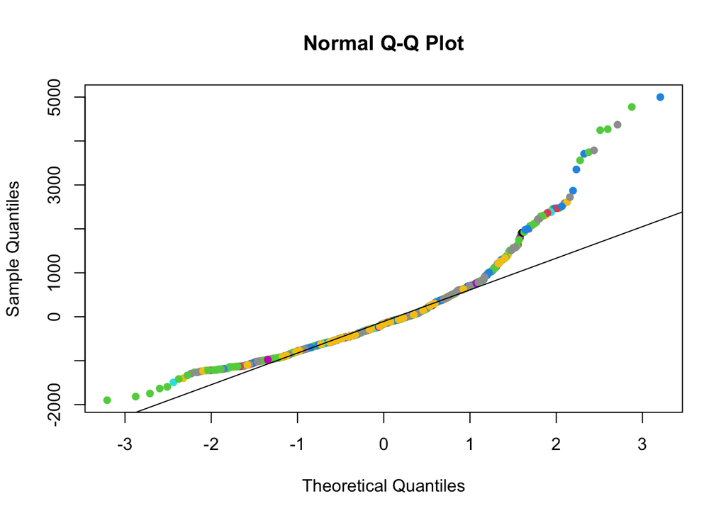

```r
# residuals of fitted values against observed
qqnorm(resid(randIntModelDurationRus),
       pch=16,
       col=durationDataEng$speaker)
qqline(resid(randIntModelDurationRus))
```

## Compare to model with only gestures shorter than 5000 ms The model that excluded the longest gestures performs better. A possible explanatiton is that very long pointing gestures are idiosyncratic or differ in duration for reasons other than information structure.

```r
durationDataRusNoOutlier <- durationDataRus %>%
  filter(dur <= 5000)

randIntModelDurationRusNoOutlier <- lmer(dur ~ infstat + (1|speaker), data = durationDataRusNoOutlier)

# Compare models using AIC
AIC(randIntModelDurationRus, randIntModelDurationRusNoOutlier)
```

```
##                                  df      AIC
## randIntModelDurationRus           4 12320.35
## randIntModelDurationRusNoOutlier  4 11910.41
```

```r
# Compare models using BIC
BIC(randIntModelDurationRus, randIntModelDurationRusNoOutlier)
```

```
##                                  df     BIC
## randIntModelDurationRus           4 12338.8
## randIntModelDurationRusNoOutlier  4 11928.8
```

## Report the model for durations of pointing gestures in Russian

```r
summary(randIntModelDurationRus)
```

```
## Linear mixed model fit by REML ['lmerMod']
## Formula: dur ~ infstat + (1 | speaker)
##    Data: durationDataRus
##
## REML criterion at convergence: 12312.3
##
## Scaled residuals:
##     Min      1Q  Median      3Q     Max
## -2.0141 -0.6276 -0.1659  0.4019  5.3007
##
## Random effects:
##  Groups   Name        Variance Std.Dev.
##  speaker  (Intercept) 110697   332.7
##  Residual             889543   943.2
## Number of obs: 745, groups:  speaker, 7
##
## Fixed effects:
##             Estimate Std. Error t value
## (Intercept)  1927.42     138.29   13.94
## infstatold   -748.63      69.89  -10.71
##
## Correlation of Fixed Effects:
##            (Intr)
## infstatold -0.216
```

```r
sjPlot::tab_model(randIntModelDurationRus)
```

|  | dur |  |  |
| --- | --- | --- | --- |
| Predictors | Estimates | CI | p |
| (Intercept) | 1927.42 | 1655.94 – 2198.91 | **<0.001** |
| infstat [old] | -748.63 | -885.83 – -611.42 | **<0.001** |
| Random Effects |  |  |  |
| σ<sup>2</sup> | 889542.55 |  |  |
| τ<sub>00</sub> <sub>speaker</sub> | 110697.26 |  |  |
| ICC | 0.11 |  |  |
| N <sub>speaker</sub> | 7 |  |  |
| Observations | 745 |  |  |
| Marginal R<sup>2</sup> / Conditional R<sup>2</sup> | 0.122 / 0.219 |  |  |

## Df with Idi durations and model

```r
durationDataIdi <- cleanDataForAnalysis %>%
  filter(infstat != "other") %>%
  filter(lang == "idi") %>%
  select(speaker, dur,infstat)

ModelDurationIdi <- glm(dur ~ infstat, family = gaussian, data = durationDataIdi)
summary(ModelDurationIdi)
```

```
##
## Call:
## glm(formula = dur ~ infstat, family = gaussian, data = durationDataIdi)
##
## Coefficients:
##             Estimate Std. Error t value Pr(>|t|)
## (Intercept)   1822.5      104.4  17.451  < 2e-16 ***
## infstatold    -527.7      150.0  -3.519  0.00056 ***
## ---
## Signif. codes:  0 '***' 0.001 '**' 0.01 '*' 0.05 '.' 0.1 ' ' 1
##
## (Dispersion parameter for gaussian family taken to be 938054.7)
##
##     Null deviance: 166393830  on 166  degrees of freedom
## Residual deviance: 154779021  on 165  degrees of freedom
## AIC: 2774.4
##
## Number of Fisher Scoring iterations: 2
```

```r
sjPlot::tab_model(ModelDurationIdi)
```

|  | dur |  |  |
| --- | --- | --- | --- |
| Predictors | Estimates | CI | p |
| (Intercept) | 1822.55 | 1617.85 – 2027.24 | **<0.001** |
| infstat [old] | -527.68 | -821.60 – -233.76 | **<0.001** |
| Observations | 167 |  |  |
| R<sup>2</sup> | 0.070 |  |  |

## Idi model diagnostics

The results of the diagnostics suggest that while the central portion of the data may be normally distributed, there are deviations from normality in the tails.

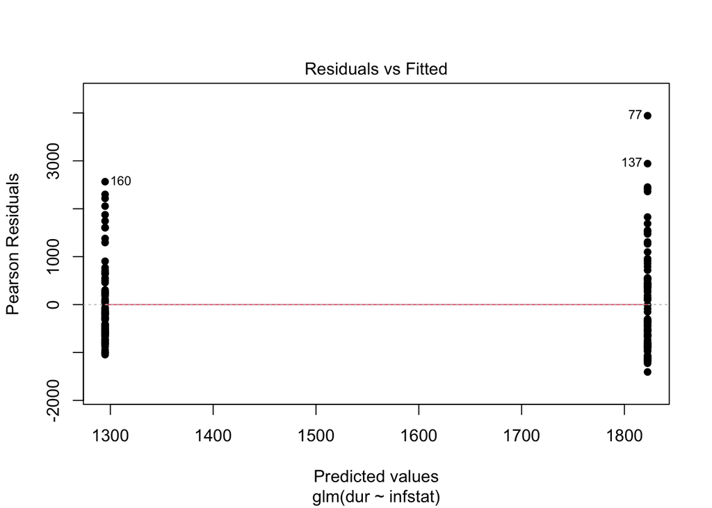

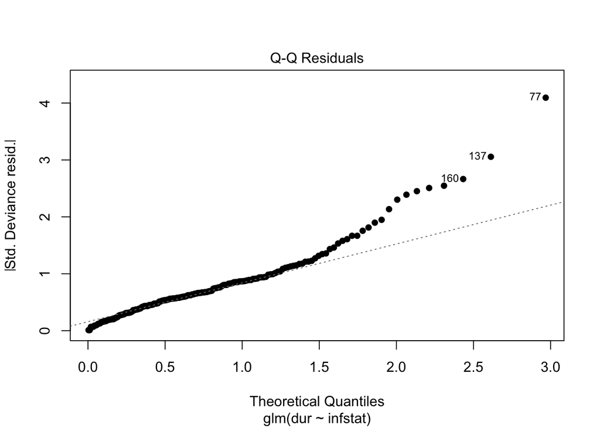

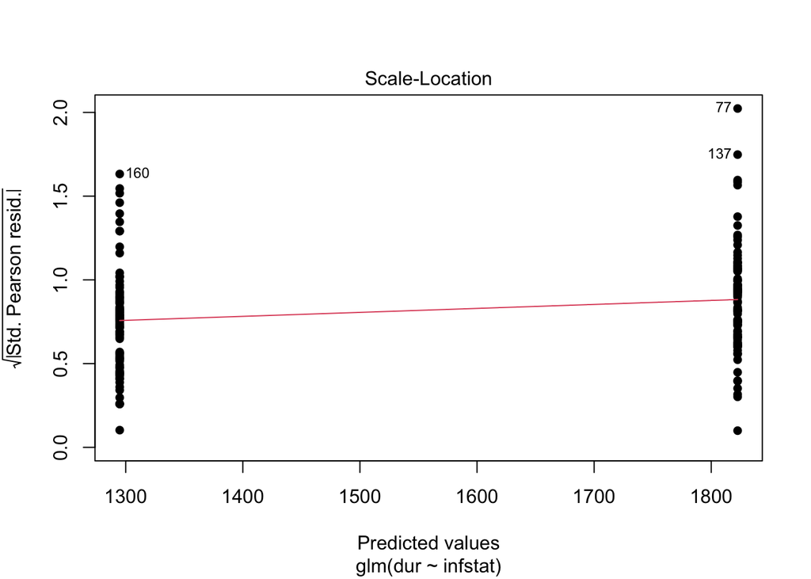

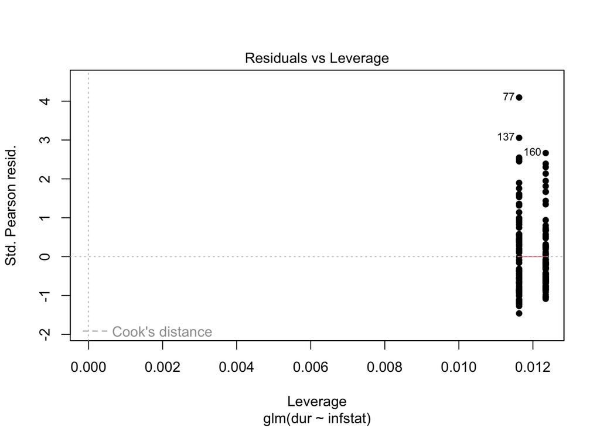

```r
# residuals per speaker
plot(ModelDurationIdi,
     abline=0,
     pch=16)
```

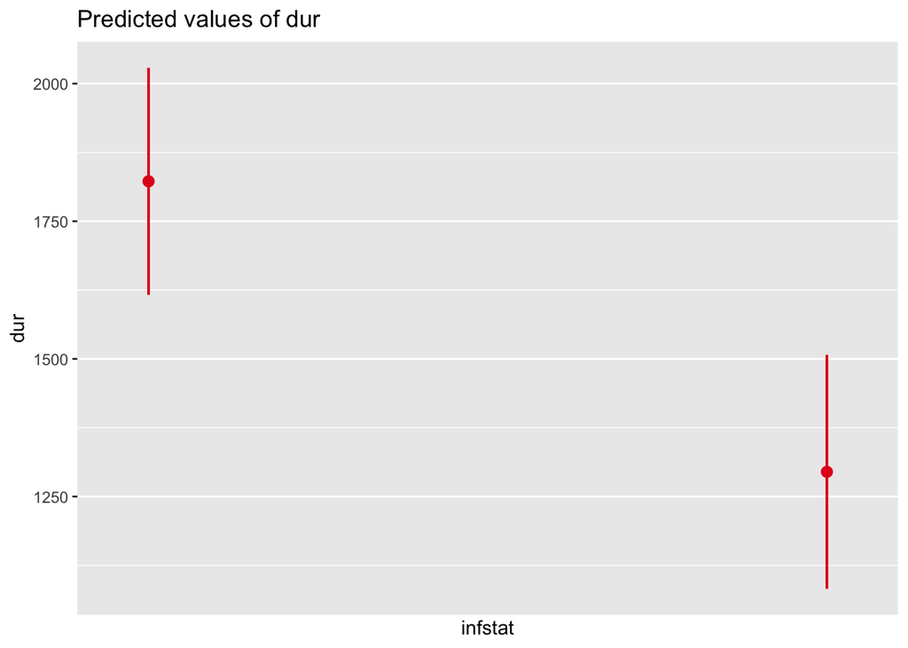

```r
# plot predicted values
sjPlot::plot_model(ModelDurationIdi,
                   type = "pred",
                   terms = c("infstat")) +
  scale_x_continuous(name = "infstat",
                     breaks = seq(-500, 300, 100),
                     labels = seq(1150, 1950, 100))
```